# Impact of Excipient Batch Variability on Capsule Quality Attributes

The emergence of the Quality by Design (QbD) concept in the early 2000s shifted the pharmaceutical industry toward a more proactive approach to product development and manufacturing. Central to the QbD framework is the identification and understanding of a product’s critical quality attributes (CQAs)—the measurable characteristics that determine product performance—and the critical process parameters (CPPs). Establishing a clear relationship between CQAs and the CPPs that affect them is essential for ensuring consistent product quality. Although this concept was initially applied primarily to newly developed drug products, it is equally relevant for legacy products, where deeper process understanding can support improved robustness and lifecycle management.

Historically, the characterization of active pharmaceutical ingredients (APIs) has been the primary focus of pharmaceutical development, while the characterization of excipients has often been more limited. As a result, excipient testing has traditionally focused on pharmacopeial requirements such as identity, purity, and chemical stability, with comparatively less emphasis on physical properties such as particle size distribution, powder flow, or moisture content.

However, excipients play a crucial role in both the biopharmaceutical performance and the manufacturing of solid dosage forms. It is now widely recognized that excipients—particularly those derived from natural sources such as microcrystalline cellulose (MCC) or lactose—may exhibit batch-to-batch variability in their physical properties. Variations between manufacturers or production lots can influence parameters such as particle size distribution, moisture content, and flowability, which in turn can significantly affect manufacturing performance and product quality, especially in tablet and capsule formulations.

In this portfolio example, a relatively simple manufacturing process is considered. The process consists of weighing and dispensing of the API and excipients, followed by dry blending, and finally capsule filling.

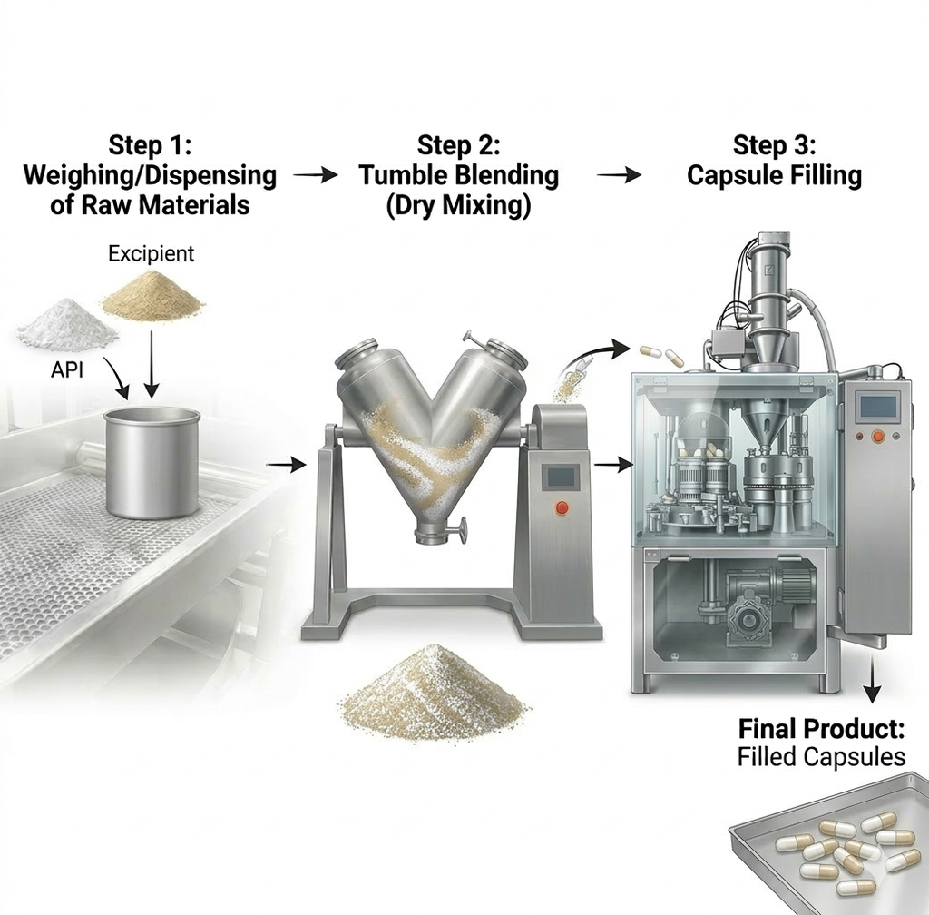

The illustrative composition of the capsule formulation is shown below:

| Component | Mass (mg) | Approx. % |
| --- | --- | --- |
| API (BCS class III) | 400 | ~63% |
| Lactose monohydrate | ~95 | ~15% |
| Capsule shell | 97 | — |
| Other excipients | ~38 | <5% each |

Given that lactose monohydrate represents the largest excipient fraction in the formulation, and that it is known to influence powder flow, dissolution behavior, and blend uniformity while also exhibiting potential batch-to-batch variability, this portfolio project focuses on evaluating the potential impact of lactose material attributes on key CQAs of the final capsule product. Note: Due to the very limited availability of real pharmaceutical manufacturing datasets, the scenario presented in this project should be considered a hypothetical case study. The dataset used for the analysis was synthetically generated based on theoretical considerations and typical pharmaceutical process ranges.

## Dataset Description and Variables

To investigate the potential impact of lactose monohydrate batch variability on capsule quality attributes, a synthetic dataset representing 150 manufacturing batches was generated. The dataset reflects plausible ranges of material attributes, process indicators, and final product quality attributes typical for solid oral dosage manufacturing. The dataset includes variables describing excipient material properties, process performance indicators, and critical quality attributes (CQAs) of the finished capsule product. Since real pharmaceutical manufacturing data is rarely publicly available due to regulatory and confidentiality constraints, the dataset was synthetically generated based on theoretical considerations and typical pharmaceutical process ranges. The simulated relationships between variables were designed to mimic realistic manufacturing behavior, where material properties can influence blend performance and ultimately product quality. The dataset contains the following variables:

| Variable | Description | Unit | Category |
| --- | --- | --- | --- |
| Batch_ID | Unique identifier for each manufacturing batch | — | Identifier |
| Lactose_PSD_um | Median particle size of lactose monohydrate used in the batch | µm | Material attribute |
| Lactose_Moisture_pct | Moisture content of lactose raw material | % | Material attribute |
| Lactose_Bulk_Density_g_ml | Bulk density of lactose powder | g/mL | Material attribute |
| Supplier | Supplier of lactose monohydrate (A, B, or C) | — | Material attribute |
| Blend_RSD_pct | Relative standard deviation of blend assay samples indicating blend uniformity | % | Process indicator |
| Capsule_Weight_mg | Average filled capsule weight | mg | CQA |
| Assay_pct | API assay of the finished capsules relative to label claim | % | CQA |
| Dissolution_30min_pct | Percentage of API dissolved after 30 minutes | % | CQA |
| Content_Uniformity_AV | Acceptance value for content uniformity according to pharmacopeial testing | — | CQA |

The material attributes of lactose are of particular interest in this analysis, as variations in particle size, moisture content, or powder density may affect powder flow, mixing efficiency, and ultimately the quality attributes of the finished dosage form. The CQAs evaluated in this study include capsule weight, assay, dissolution performance, and content uniformity, which are commonly monitored during pharmaceutical manufacturing to ensure compliance with regulatory specifications and consistent product performance.

## Exploratory Data Analysis

```python
#Import neccessary packages
import numpy as np
import pandas as pd
import matplotlib.pyplot as plt
import seaborn as sns
import statsmodels.api as sm
from scipy import stats
```

```python
#Open the file and create dataframe
df=pd.read_csv(r"C:\Users\milic\OneDrive\Radna površina\Potencijalni datasetovi\pharma_capsule_batch_dataset_150_batches.csv")
```

```python
df.head(10)
```

|  | Batch_ID | Lactose_PSD_um | Lactose_Moisture_pct | Lactose_Bulk_Density_g_ml | Supplier | Blend_RSD_pct | Capsule_Weight_mg | Assay_pct | Dissolution_30min_pct | Content_Uniformity_AV |
| --- | --- | --- | --- | --- | --- | --- | --- | --- | --- | --- |
| 0 | B001 | 157.38 | 4.68 | 0.542 | C | 2.57 | 620.1 | 99.95 | 89.93 | 7.60 |
| 1 | B002 | 135.16 | 4.74 | 0.561 | C | 3.49 | 641.1 | 98.89 | 94.38 | 9.53 |
| 2 | B003 | 162.67 | 4.02 | 0.652 | C | 3.64 | 630.8 | 96.79 | 93.52 | 10.11 |
| 3 | B004 | 193.31 | 4.66 | 0.643 | A | 2.19 | 641.4 | 101.14 | 91.38 | 7.79 |
| 4 | B005 | 131.80 | 4.71 | 0.599 | B | 4.85 | 644.7 | 98.39 | 93.49 | 11.42 |
| 5 | B006 | 131.81 | 4.00 | 0.608 | A | 3.27 | 603.9 | 99.60 | 93.91 | 10.11 |
| 6 | B007 | 195.27 | 5.81 | 0.689 | B | 2.79 | 620.8 | 100.57 | 88.81 | 6.12 |
| 7 | B008 | 166.86 | 4.83 | 0.559 | C | 3.14 | 622.5 | 95.83 | 91.00 | 9.90 |
| 8 | B009 | 123.57 | 3.67 | 0.638 | C | 3.76 | 660.9 | 96.28 | 90.95 | 9.93 |
| 9 | B010 | 158.99 | 4.96 | 0.586 | A | 3.01 | 631.8 | 99.40 | 90.93 | 7.28 |

```python
#Obtain basic dataset info
df.info()
```

```
<class 'pandas.DataFrame'>
RangeIndex: 150 entries, 0 to 149
Data columns (total 10 columns):
 #   Column                     Non-Null Count  Dtype
---  ------                     --------------  -----
 0   Batch_ID                   150 non-null    str
 1   Lactose_PSD_um             150 non-null    float64
 2   Lactose_Moisture_pct       150 non-null    float64
 3   Lactose_Bulk_Density_g_ml  150 non-null    float64
 4   Supplier                   150 non-null    str
 5   Blend_RSD_pct              150 non-null    float64
 6   Capsule_Weight_mg          150 non-null    float64
 7   Assay_pct                  150 non-null    float64
 8   Dissolution_30min_pct      150 non-null    float64
 9   Content_Uniformity_AV      150 non-null    float64
dtypes: float64(8), str(2)
memory usage: 11.8 KB
```

```python
df.shape
```

```
(150, 10)
```

```python
#Obtain summary stats for numerical variables
df.describe()
```

|  | Lactose_PSD_um | Lactose_Moisture_pct | Lactose_Bulk_Density_g_ml | Blend_RSD_pct | Capsule_Weight_mg | Assay_pct | Dissolution_30min_pct | Content_Uniformity_AV |
| --- | --- | --- | --- | --- | --- | --- | --- | --- |
| count | 150.000000 | 150.000000 | 150.000000 | 150.000000 | 150.000000 | 150.000000 | 150.000000 | 150.000000 |
| mean | 137.118867 | 4.549733 | 0.603860 | 3.088600 | 630.816000 | 99.966267 | 92.241200 | 8.706467 |
| std | 32.981823 | 0.715365 | 0.066464 | 1.111649 | 12.358016 | 1.763849 | 2.090893 | 1.833556 |
| min | 48.310000 | 2.230000 | 0.451000 | 0.800000 | 597.500000 | 95.830000 | 87.100000 | 4.180000 |
| 25% | 116.587500 | 4.012500 | 0.558000 | 2.370000 | 624.000000 | 98.795000 | 90.935000 | 7.352500 |
| 50% | 138.115000 | 4.600000 | 0.602500 | 3.150000 | 631.550000 | 99.970000 | 92.130000 | 8.685000 |
| 75% | 157.180000 | 4.975000 | 0.648000 | 3.760000 | 640.075000 | 101.197500 | 93.842500 | 10.015000 |
| max | 226.210000 | 7.200000 | 0.753000 | 6.170000 | 663.100000 | 105.130000 | 97.220000 | 14.420000 |

```python
#Check for missing values
df.isna().any(axis=1).sum()
```

```
np.int64(0)
```

```python
#Check for duplicates
df.duplicated().sum()
```

```
np.int64(0)
```

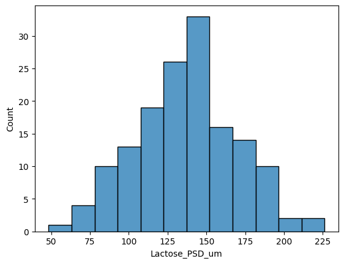

```python
#Let's check the distribution of lactose particle size
sns.histplot(data=df, x='Lactose_PSD_um')
plt.show()
```

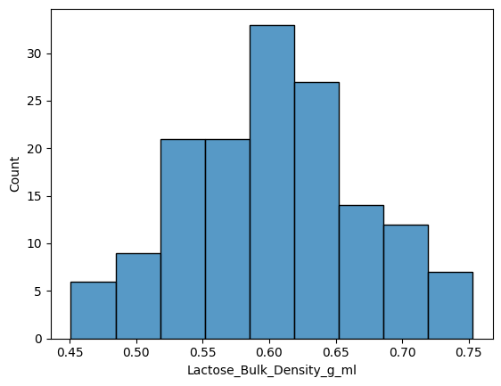

```python
#Let's check the distribution of lactose bulk density
sns.histplot(data=df, x='Lactose_Bulk_Density_g_ml')
plt.show()
```

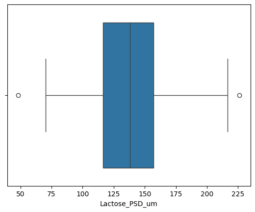

```python
#Let's check if the outliers are present in different lactose properties
box=sns.boxplot(x=df['Lactose_PSD_um'])
```

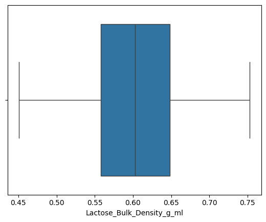

```python
box=sns.boxplot(x=df['Lactose_Bulk_Density_g_ml'])
```

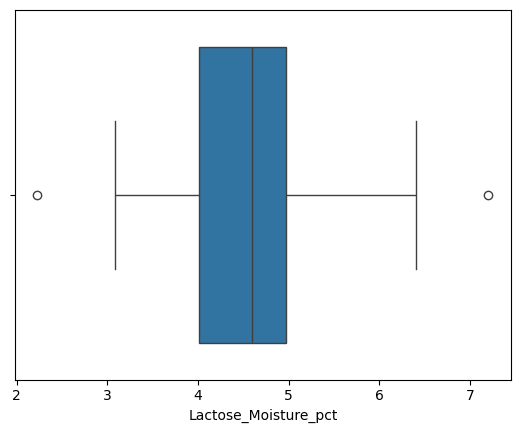

```python
box=sns.boxplot(x=df['Lactose_Moisture_pct'])
```

From the exploratory data analysis (EDA), the lactose properties—median particle size, moisture content, and bulk density—appear to be approximately normally distributed, with very few outliers. In a real-world scenario, this could reflect thorough excipient characterization and strict quality control (or in this case, more likely - syntethic dataset).

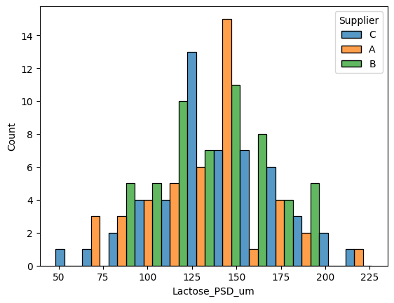

```python
#Let's check if the lactose supplier has impact on different lactose properties
sns.histplot(data=df, x='Lactose_PSD_um',hue='Supplier',multiple='dodge')
plt.show()
```

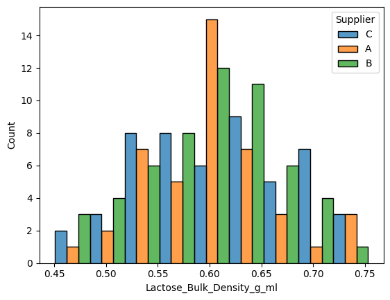

```python
sns.histplot(data=df, x='Lactose_Bulk_Density_g_ml',hue='Supplier',multiple='dodge')
plt.show()
```

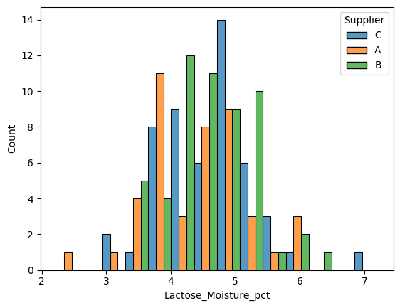

```python
sns.histplot(data=df, x='Lactose_Moisture_pct',hue='Supplier',multiple='dodge')
plt.show()
```

From the histograms above, it appears that different lactose suppliers may influence particle size, moisture content, and bulk density of the excipient. While these visual trends are suggestive, they are illustrative in nature, and further statistical testing would be required to draw definitive conclusions regarding supplier-related differences.

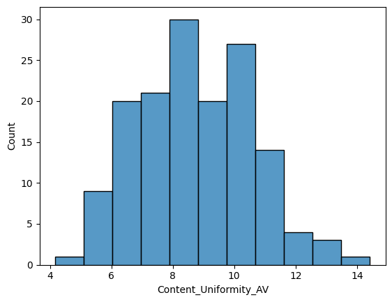

```python
#Let's explore capsule content uniformity data - first, the data distribution
sns.histplot(data=df, x='Content_Uniformity_AV')
plt.show()
```

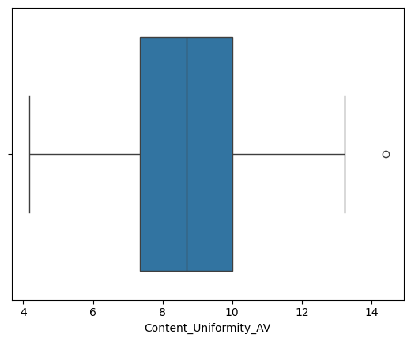

```python
#Let's check if there are outliers for capsule content uniformity
box=sns.boxplot(x=df['Content_Uniformity_AV'])
```

For the initial exploratory data analysis (EDA), I focused on capsule content uniformity (CU) among the listed CQAs. This variable is most likely to be influenced by lactose material properties, whereas other CQAs such as capsule weight and assay are tightly controlled during manufacturing according to product specifications and are therefore less sensitive to small variations in excipient properties. From the graphs, CU appears to be approximately normally distributed, with very few outliers, providing a good foundation for further statistical analysis.

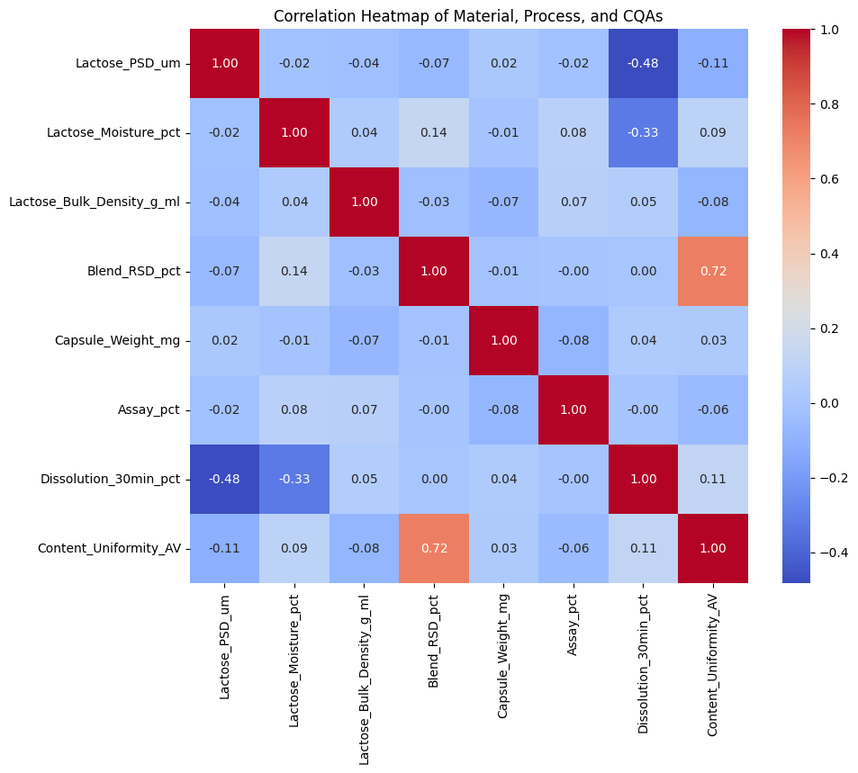

```python
# Compute correlation matrix for numerical variables
corr = df[['Lactose_PSD_um','Lactose_Moisture_pct','Lactose_Bulk_Density_g_ml',
           'Blend_RSD_pct','Capsule_Weight_mg','Assay_pct','Dissolution_30min_pct',
           'Content_Uniformity_AV']].corr()

plt.figure(figsize=(10,8))
sns.heatmap(corr, annot=True, fmt=".2f", cmap='coolwarm', cbar=True)
plt.title('Correlation Heatmap of Material, Process, and CQAs')
plt.show()
```

The correlation heatmap shows a moderate-to-strong positive correlation (r = 0.72) between Blend_RSD_pct and Content_Uniformity_AV. This aligns with expectations: batches with more uniform blends (lower RSD) tend to produce capsules with better content uniformity (lower AV), while less homogeneous blends are associated with higher AV values, reflecting greater variability in capsule content.

## Statistical Analysis

### Supplier influence in lactose properties

```python
#Let's try to see if the supplier affects the different lactose properties
ols_data =df[['Supplier', 'Lactose_PSD_um']]
ols_formula = 'Lactose_PSD_um~Supplier'
from statsmodels.formula.api import ols
OLS = ols(formula=ols_formula, data=ols_data)
model=OLS.fit()
model.summary()
```

OLS Regression Results

| Dep. Variable: | Lactose_PSD_um | R-squared: | 0.010 |
| --- | --- | --- | --- |
| Model: | OLS | Adj. R-squared: | -0.004 |
| Method: | Least Squares | F-statistic: | 0.7178 |
| Date: | Mon, 23 Mar 2026 | Prob (F-statistic): | 0.490 |
| Time: | 21:28:41 | Log-Likelihood: | -736.00 |
| No. Observations: | 150 | AIC: | 1478. |
| Df Residuals: | 147 | BIC: | 1487. |
| Df Model: | 2 |  |  |
| Covariance Type: | nonrobust |  |  |

|  | coef | std err | t | P>\|t\| | [0.025 | 0.975] |
| --- | --- | --- | --- | --- | --- | --- |
| Intercept | 133.2198 | 4.982 | 26.742 | 0.000 | 123.375 | 143.065 |
| Supplier[T.B] | 3.1868 | 6.684 | 0.477 | 0.634 | -10.022 | 16.395 |
| Supplier[T.C] | 8.0312 | 6.799 | 1.181 | 0.239 | -5.405 | 21.468 |

| Omnibus: | 0.027 | Durbin-Watson: | 2.160 |
| --- | --- | --- | --- |
| Prob(Omnibus): | 0.986 | Jarque-Bera (JB): | 0.064 |
| Skew: | 0.030 | Prob(JB): | 0.968 |
| Kurtosis: | 2.919 | Cond. No. | 3.95 |

Notes:  
[1] Standard Errors assume that the covariance matrix of the errors is correctly specified.

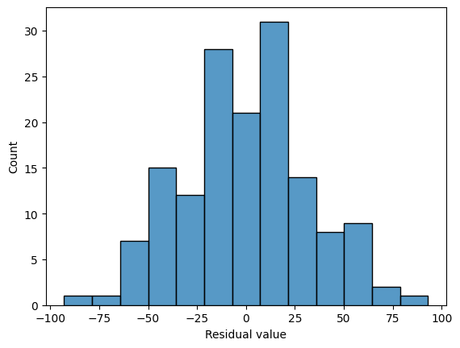

```python
#Let's check the ANOVA assumptions - first off, normality of residues
residuals=model.resid
fig=sns.histplot(residuals)
fig.set_xlabel('Residual value')
plt.show()
```

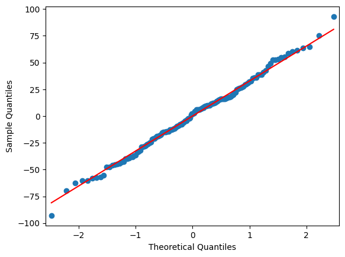

```python
#From the histogram above, residues look normaly distributed. Let's check that additionally using Q-Q plot
import statsmodels.api as sm
sm.qqplot(residuals, line='s')
plt.show()
```

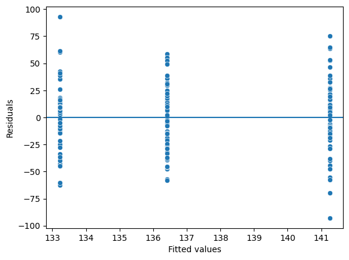

```python
#Let's check the homoscedasticity assumption as well
fitted_values=model.predict(ols_data['Supplier'])
fig=sns.scatterplot(x=fitted_values, y=residuals)
fig.axhline(0)
fig.set_xlabel('Fitted values')
fig.set_ylabel('Residuals')
plt.show()
```

The assumptions required for one-way ANOVA were evaluated, and the criteria for residual normality and homoscedasticity were satisfied. However, the analysis did not indicate a statistically significant difference in lactose particle size between suppliers (p = 0.49). Therefore, no post hoc pairwise comparisons (e.g., Tukey’s HSD test) were performed.

```python
#Let's try to see if the supplier makes any difference when it comes to lactose bulk density
ols_data_2 =df[['Supplier', 'Lactose_Bulk_Density_g_ml']]
ols_formula_2 = 'Lactose_Bulk_Density_g_ml~Supplier'
from statsmodels.formula.api import ols
OLS_2 = ols(formula=ols_formula_2, data=ols_data_2)
model_2=OLS_2.fit()
model_2.summary()
```

OLS Regression Results

| Dep. Variable: | Lactose_Bulk_Density_g_ml | R-squared: | 0.006 |
| --- | --- | --- | --- |
| Model: | OLS | Adj. R-squared: | -0.007 |
| Method: | Least Squares | F-statistic: | 0.4585 |
| Date: | Mon, 23 Mar 2026 | Prob (F-statistic): | 0.633 |
| Time: | 21:29:09 | Log-Likelihood: | 194.79 |
| No. Observations: | 150 | AIC: | -383.6 |
| Df Residuals: | 147 | BIC: | -374.5 |
| Df Model: | 2 |  |  |
| Covariance Type: | nonrobust |  |  |

|  | coef | std err | t | P>\|t\| | [0.025 | 0.975] |
| --- | --- | --- | --- | --- | --- | --- |
| Intercept | 0.6023 | 0.010 | 59.887 | 0.000 | 0.582 | 0.622 |
| Supplier[T.B] | -0.0036 | 0.013 | -0.265 | 0.791 | -0.030 | 0.023 |
| Supplier[T.C] | 0.0086 | 0.014 | 0.626 | 0.532 | -0.019 | 0.036 |

| Omnibus: | 1.366 | Durbin-Watson: | 1.814 |
| --- | --- | --- | --- |
| Prob(Omnibus): | 0.505 | Jarque-Bera (JB): | 1.195 |
| Skew: | -0.007 | Prob(JB): | 0.550 |
| Kurtosis: | 2.563 | Cond. No. | 3.95 |

Notes:  
[1] Standard Errors assume that the covariance matrix of the errors is correctly specified.

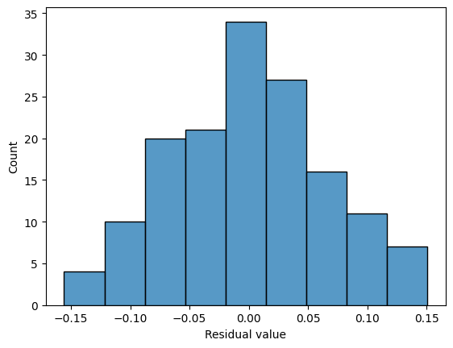

```python
#Let's check the ANOVA assumptions again - first off, normality of residues
residuals_2=model_2.resid
fig=sns.histplot(residuals_2)
fig.set_xlabel('Residual value')
plt.show()
```

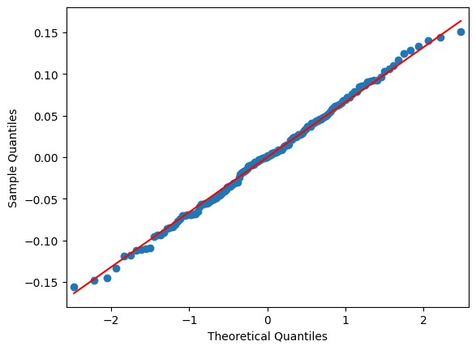

```python
#From the histogram above, residues look normaly distributed. Let's check that additionally using Q-Q plot
sm.qqplot(residuals_2, line='s')
plt.show()
```

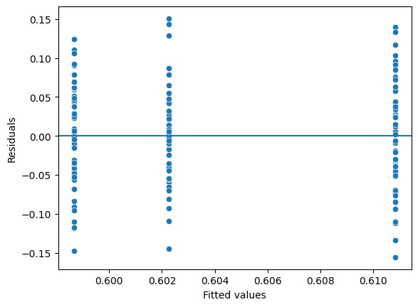

```python
#Let's check the homoscedasticity assumption as well
fitted_values_2=model_2.predict(ols_data_2['Supplier'])
fig=sns.scatterplot(x=fitted_values_2, y=residuals_2)
fig.axhline(0)
fig.set_xlabel('Fitted values')
fig.set_ylabel('Residuals')
plt.show()
```

Similar to lactose particle size, One-way ANOVA did not indicate a statistically significant difference in lactose bulk density between suppliers (p = 0.633).

```python
#And lastly, let's try to see if the supplier makes any difference when it comes to lactose moisture content
ols_data_3 =df[['Supplier', 'Lactose_Moisture_pct']]
ols_formula_3 = 'Lactose_Moisture_pct~Supplier'
from statsmodels.formula.api import ols
OLS_3 = ols(formula=ols_formula_3, data=ols_data_3)
model_3=OLS_3.fit()
model_3.summary()
```

OLS Regression Results

| Dep. Variable: | Lactose_Moisture_pct | R-squared: | 0.014 |
| --- | --- | --- | --- |
| Model: | OLS | Adj. R-squared: | 0.001 |
| Method: | Least Squares | F-statistic: | 1.048 |
| Date: | Mon, 23 Mar 2026 | Prob (F-statistic): | 0.353 |
| Time: | 21:29:23 | Log-Likelihood: | -161.03 |
| No. Observations: | 150 | AIC: | 328.1 |
| Df Residuals: | 147 | BIC: | 337.1 |
| Df Model: | 2 |  |  |
| Covariance Type: | nonrobust |  |  |

|  | coef | std err | t | P>\|t\| | [0.025 | 0.975] |
| --- | --- | --- | --- | --- | --- | --- |
| Intercept | 4.4189 | 0.108 | 40.987 | 0.000 | 4.206 | 4.632 |
| Supplier[T.B] | 0.1924 | 0.145 | 1.330 | 0.186 | -0.093 | 0.478 |
| Supplier[T.C] | 0.1774 | 0.147 | 1.206 | 0.230 | -0.113 | 0.468 |

| Omnibus: | 6.174 | Durbin-Watson: | 2.184 |
| --- | --- | --- | --- |
| Prob(Omnibus): | 0.046 | Jarque-Bera (JB): | 7.009 |
| Skew: | 0.291 | Prob(JB): | 0.0301 |
| Kurtosis: | 3.884 | Cond. No. | 3.95 |

Notes:  
[1] Standard Errors assume that the covariance matrix of the errors is correctly specified.

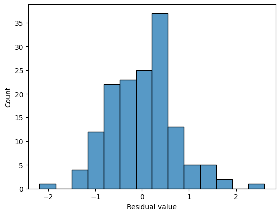

```python
#Let's check the ANOVA assumptions again - first off, normality of residues
residuals_3=model_3.resid
fig=sns.histplot(residuals_3)
fig.set_xlabel('Residual value')
plt.show()
```

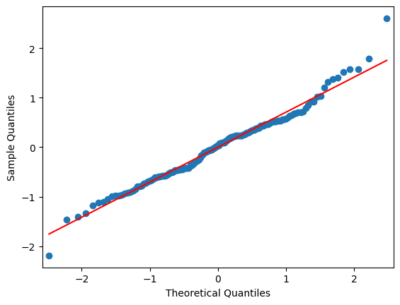

```python
#From the histogram above, residues look normaly distributed. Let's check that additionally using Q-Q plot
sm.qqplot(residuals_3, line='s')
plt.show()
```

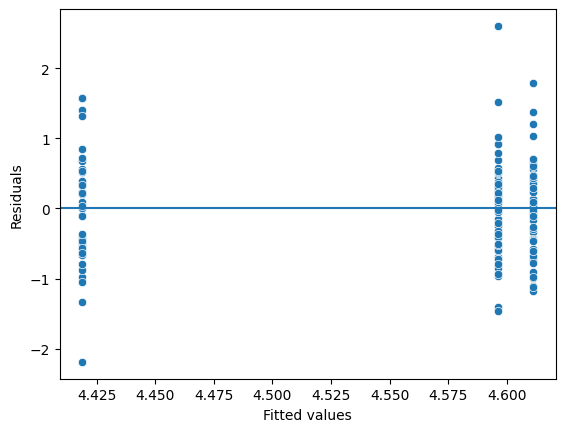

```python
#Let's check the homoscedasticity assumption as well
fitted_values_3=model_3.predict(ols_data_3['Supplier'])
fig=sns.scatterplot(x=fitted_values_3, y=residuals_3)
fig.axhline(0)
fig.set_xlabel('Fitted values')
fig.set_ylabel('Residuals')
plt.show()
```

One-way ANOVA was performed to assess the effect of supplier on lactose material attributes, including particle size, moisture content, and bulk density.

No statistically significant differences were observed for any of the evaluated properties (p > 0.05 in all cases), indicating that supplier-related variability does not significantly impact lactose material characteristics in this dataset.

### Blend RSD vs. Capsule Content Uniformity

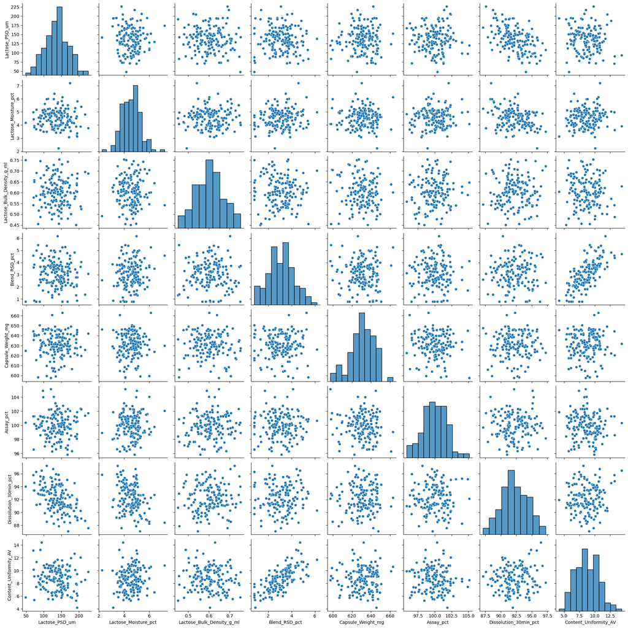

```python
#Since the correlation heatmap showed a moderate-to-strong positive correlation (r = 0.72) between Blend_RSD_pct and Content_Uniformity_AV, let's explore the relationship between the two
#First, let's check if there is some linearity between the two

sns.pairplot(df)
```

From the pairplot above, it looks like there is linearity between Blend_RSD_pct and Content_Uniformity_AV. We can now proceed to build a linear regression model.

```python
ols_data_4 =df[['Blend_RSD_pct', 'Content_Uniformity_AV']]
ols_formula_4 = 'Content_Uniformity_AV~Blend_RSD_pct'
from statsmodels.formula.api import ols
OLS_4 = ols(formula=ols_formula_4, data=ols_data_4)
model_4=OLS_4.fit()
model_4.summary()
```

OLS Regression Results

| Dep. Variable: | Content_Uniformity_AV | R-squared: | 0.518 |
| --- | --- | --- | --- |
| Model: | OLS | Adj. R-squared: | 0.515 |
| Method: | Least Squares | F-statistic: | 159.2 |
| Date: | Mon, 23 Mar 2026 | Prob (F-statistic): | 3.08e-25 |
| Time: | 21:30:01 | Log-Likelihood: | -248.51 |
| No. Observations: | 150 | AIC: | 501.0 |
| Df Residuals: | 148 | BIC: | 507.0 |
| Df Model: | 1 |  |  |
| Covariance Type: | nonrobust |  |  |

|  | coef | std err | t | P>\|t\| | [0.025 | 0.975] |
| --- | --- | --- | --- | --- | --- | --- |
| Intercept | 5.0392 | 0.309 | 16.319 | 0.000 | 4.429 | 5.649 |
| Blend_RSD_pct | 1.1873 | 0.094 | 12.617 | 0.000 | 1.001 | 1.373 |

| Omnibus: | 0.356 | Durbin-Watson: | 2.158 |
| --- | --- | --- | --- |
| Prob(Omnibus): | 0.837 | Jarque-Bera (JB): | 0.443 |
| Skew: | 0.111 | Prob(JB): | 0.801 |
| Kurtosis: | 2.854 | Cond. No. | 10.5 |

Notes:  
[1] Standard Errors assume that the covariance matrix of the errors is correctly specified.

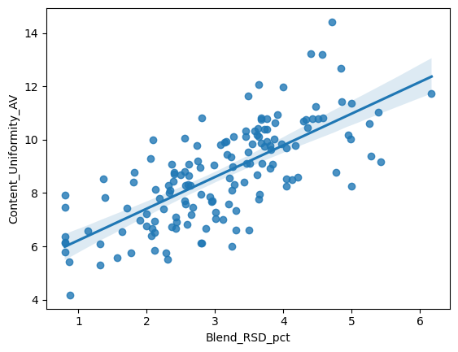

```python
#Let's see if we can fit the best fit regression line
sns.regplot(x='Blend_RSD_pct',y='Content_Uniformity_AV', data=ols_data_4)
```

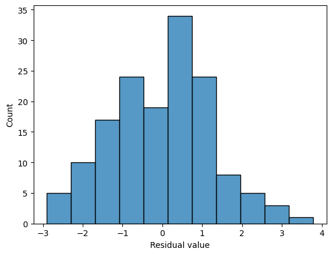

```python
#Let's check the linear regression assumptions - first off, normality of residues
residuals_4=model_4.resid
fig=sns.histplot(residuals_4)
fig.set_xlabel('Residual value')
plt.show()
```

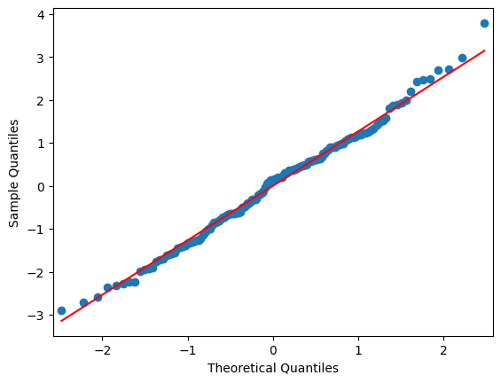

```python
#From the histogram above, residues look normaly distributed. Let's check that additionally using Q-Q plot
sm.qqplot(residuals_4, line='s')
plt.show()
```

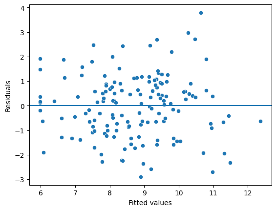

```python
#Let's check the homoscedasticity assumption as well
fitted_values_4=model_4.predict(ols_data_4['Blend_RSD_pct'])
fig=sns.scatterplot(x=fitted_values_4, y=residuals_4)
fig.axhline(0)
fig.set_xlabel('Fitted values')
fig.set_ylabel('Residuals')
plt.show()
```

As we could see from the regression line fit, residuals normality histogram and Q-Q plot and homoscedasticity, we can conclude that basic linear regression assumptions were fulfilled.The regression analysis demonstrates a statistically significant linear relationship between blend uniformity (Blend RSD) and capsule content uniformity (AV) (p < 0.001, R² = 0.52). The model indicates that a 1% increase in blend RSD is associated with an increase of approximately 1.19 units in AV, highlighting the critical role of blend homogeneity in ensuring consistent dosage. While Blend RSD explains a substantial portion of variability, approximately 48% of the variability in content uniformity remains unexplained, suggesting that additional factors may also contribute.

### Lactose Moisture vs. Dissolution

Another relashionship that is worth revisiting is potential impact of lactose moisture content on capsule dissolution. It is worth mentioning, that moisture content of excipients can affect many tablet properties, such as hardness, disintegration, and dissolution. For capsules, the gelatin shell usually dissolves easily, so small variations in excipient moisture may have less direct impact on dissolution, especially for BCS Class III drugs (high solubility, low permeability).However, lactose moisture can still play a role - for example, high moisture in the fill material can sometimes promote cross-linking in the gelatin shell over time, which slows down dissolution. Plug formation can be affected as well, especially in capsuling machines with tamping-pin filler; moisture levels in the lactose significantly affect the "plug" hardness. A very dry or very damp plug may disintegrate differently once the shell dissolves.

```python
#Let's construct the model first
ols_data_5 =df[['Lactose_Moisture_pct', 'Dissolution_30min_pct']]
ols_formula_5 = 'Dissolution_30min_pct~Lactose_Moisture_pct'
from statsmodels.formula.api import ols
OLS_5 = ols(formula=ols_formula_5, data=ols_data_5)
model_5=OLS_5.fit()
model_5.summary()
```

OLS Regression Results

| Dep. Variable: | Dissolution_30min_pct | R-squared: | 0.106 |
| --- | --- | --- | --- |
| Model: | OLS | Adj. R-squared: | 0.100 |
| Method: | Least Squares | F-statistic: | 17.61 |
| Date: | Mon, 23 Mar 2026 | Prob (F-statistic): | 4.65e-05 |
| Time: | 22:15:18 | Log-Likelihood: | -314.55 |
| No. Observations: | 150 | AIC: | 633.1 |
| Df Residuals: | 148 | BIC: | 639.1 |
| Df Model: | 1 |  |  |
| Covariance Type: | nonrobust |  |  |

|  | coef | std err | t | P>\|t\| | [0.025 | 0.975] |
| --- | --- | --- | --- | --- | --- | --- |
| Intercept | 96.5778 | 1.046 | 92.335 | 0.000 | 94.511 | 98.645 |
| Lactose_Moisture_pct | -0.9532 | 0.227 | -4.197 | 0.000 | -1.402 | -0.504 |

| Omnibus: | 1.359 | Durbin-Watson: | 2.058 |
| --- | --- | --- | --- |
| Prob(Omnibus): | 0.507 | Jarque-Bera (JB): | 1.293 |
| Skew: | -0.107 | Prob(JB): | 0.524 |
| Kurtosis: | 2.599 | Cond. No. | 31.1 |

Notes:  
[1] Standard Errors assume that the covariance matrix of the errors is correctly specified.

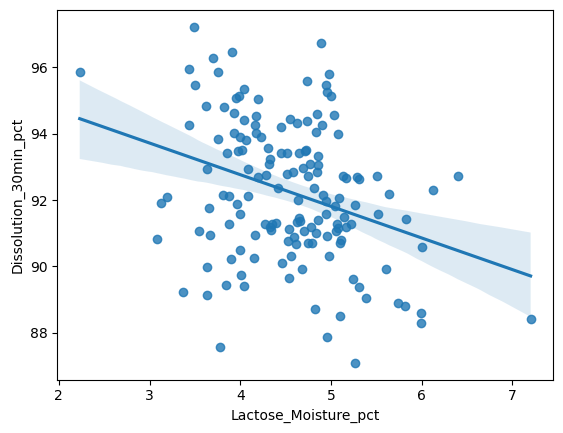

```python
#Let's see if we can fit the best fit regression line
sns.regplot(x='Lactose_Moisture_pct',y='Dissolution_30min_pct', data=ols_data_5)
```

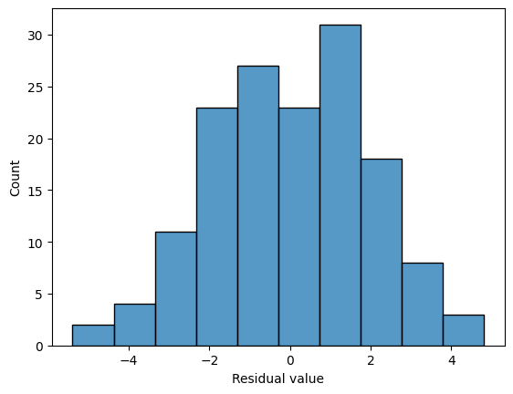

```python
#Let's check the linear regression assumptions - first off, normality of residues
residuals_5=model_5.resid
fig=sns.histplot(residuals_5)
fig.set_xlabel('Residual value')
plt.show()
```

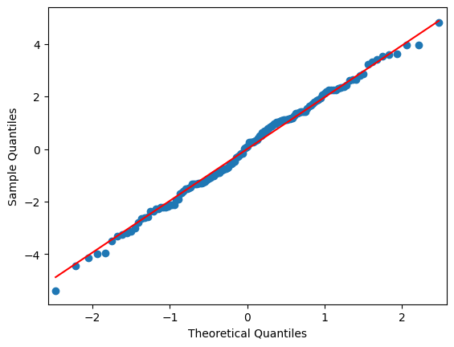

```python
#From the histogram above, residues look normaly distributed. Let's check that additionally using Q-Q plot
sm.qqplot(residuals_5, line='s')
plt.show()
```

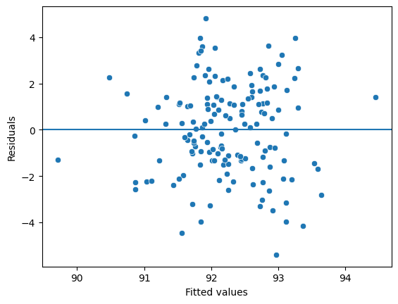

```python
#Let's check the homoscedasticity assumption as well
fitted_values_5=model_5.predict(ols_data_5['Lactose_Moisture_pct'])
fig=sns.scatterplot(x=fitted_values_5, y=residuals_5)
fig.axhline(0)
fig.set_xlabel('Fitted values')
fig.set_ylabel('Residuals')
plt.show()
```

The regression analysis indicates a statistically significant relationship between lactose moisture content and capsule dissolution at 30 minutes (p < 0.001). The model suggests that a 1% increase in lactose moisture is associated with an approximate 0.95% decrease in dissolution.

However, the explanatory power of the model is relatively low (R² = 0.106), indicating that lactose moisture content accounts for only a small portion of the variability in dissolution performance. The low R² suggests that while moisture has an effect, the primary rate-limiting step for dissolution is likely the capsule shell itself.

These results suggest that lactose moisture is not a critical driver of dissolution variability in this system, and that other factors—such as capsule shell properties or formulation design—are likely to play a more dominant role.

## Final conclusion

This analysis explored the impact of excipient batch variability—specifically lactose material attributes—on key capsule quality attributes, including blend uniformity, content uniformity, and dissolution performance.

The results demonstrate that blend uniformity (Blend RSD) is a critical driver of capsule content uniformity, with regression analysis showing a strong and statistically significant relationship (R² = 0.52, p < 0.001). This confirms the fundamental pharmaceutical principle that adequate powder mixing is essential for ensuring consistent dosage in solid oral forms.

Overall, these findings highlight that:

Not all statistically significant relationships are equally impactful from a process or product quality perspective. A data-driven approach, combined with domain knowledge, is essential for correctly interpreting variability in pharmaceutical systems.

This project demonstrates how statistical analysis can be applied to support Quality by Design (QbD) principles by identifying and quantifying the factors that most influence product quality.